# Форматирование программного кода

# Прочее

- названия всех параметров классов начинаются с "p_".
- названия всех методов начинаются c "m_".
- глобальные переменные сторонних подключаемых библиотек в С и C++ начинаются с "_".
- ассемблерные вставки в С и С++ начинаются с $"__ASM{...}"$
- все макросы FASM начинаются с $"__"$
- все локальные переменные начинаются с "_", ускорение написания кода с использованием автоподстановки, сразу видны все самописные локальные переменные при рефакторинге.
- delphi 7 , все названия типов классов начинаются с "T".
- delphi 7 , все названия экзампляров классов начинаются с названия типа класса, только без "T".
- названия интерфейсов начинаются с "I". Даже если это "III".

# Просто к слову...

Если назвать метод полным именем или аббревиатурой не удается, то можно взять только первые 3 слова из названия, из них взять только первые 3 буквы, но подробно описать в комментариях, что это значит.

# Предупреждение!!!

Все используемые нотации выбираются, исходя из командного и индивидуального удобства. Несовпадение нотаций неизбежно приведет к непониманию. Поэтому нужно придерживаться официально принятой нотации в официальных документах, примерах программных кодов, а также подстраиваться по ситуации.

# Предупреждение!!!

Несовпадение нотаций, Вашей и той, на которой работают в данной команде, неизбежно приведет к непониманию. Поэтому нужно подстраиваться по ситуации.

# Быстрый рефакторинг. Часть первая.

- Переименование переменных Кликаем мышкой на переменную или на её объявление. Затем нажимаем левой кнопкой мыши. Выбераем "переименование". Затем вводим новое название переменной и нажимаем "переименовать".

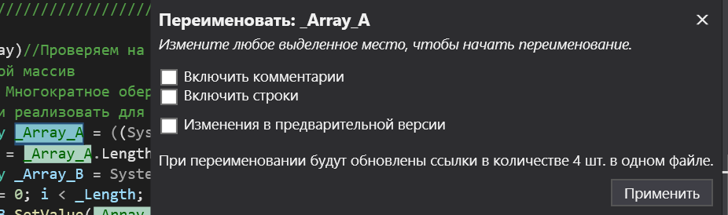

- Быстрый поиск и замена вхождений строки на новые. Нажимаем сочетания клавиш "Ctrl+F", разворачиваем вкладку поиска (1).

В верхнем текстовом поле вводим строку для поиска. В нижнем текстовом поле вводим строку для замены.  
Кнопка (2) - заменить следующую искомую подстроку на новую.  
Кнопка (3) - заменить все искомые подстроки на новые.  
Таким образом можно видоизменять коды в отдельном файле или во всем проекте в полуавтоматическом режиме.

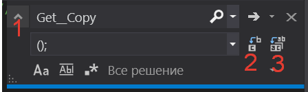

- Т4. Автогенерации программных кодов для Visual Studio 2012 и позднее. Технология имеет место быть

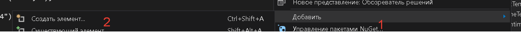

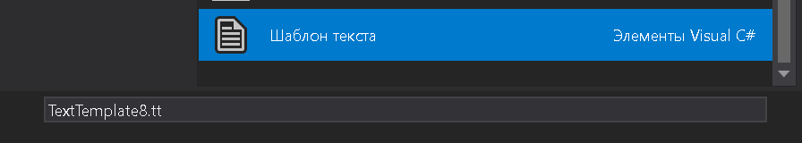

  Подробнее https://github.com/IvanSibirevV2/HowTo_CSharp/tree/main/T4_Full. Там собран полный список примеров. Любая другая документация в интернете будет лишь отрывочной. Т4 - можно считать морально устаревшим, но в качестве быстрой "заплатки" перед рефакторингом вполне пригоден. Если в проекте встречается Т4 - то это признак необходимости проводить рефакторинг в сторону более общих программных кодов, рефлексии и других абстрактных подходов в программировании.
- быстрый рефакторинг или быстрые действия. Visual Studio предоставляет подсказки в процессе написания программных кодов. Во-первых это автоподстановка... Во-вторых, более поздние версии, например, Visual Studio 2020-2021, позволяют предположить наиболее вероятную синтаксическую конструкцию и подтвердить её нажатием на "Tab". В-третьих, это подсказки в виде быстрых изменений (быстрый рефакторинг).

Кликаем правой кнопкой мыши на программном коде и выбираем:... Получаем следующее меню.

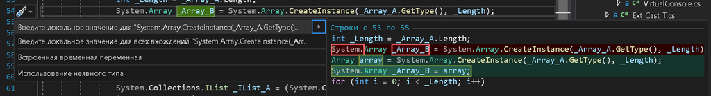

Эти быстрые подсказки не всегда толковые, но они есть. Их чтение может открыть много нового. Так я узнал о следующем синтаксисе написания функций (обратите внимание на красную стрелочку).

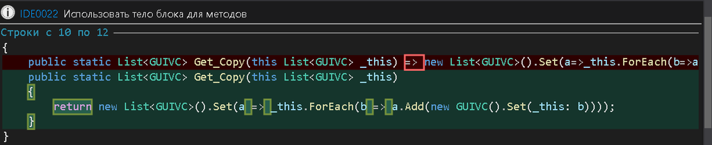

Подробнее о быстрых действиях и рефакторинге можно прочитать в статье: https://docs.microsoft.com/ru-ru/visualstudio/ide/quick-actions?view=vs-2019

# Примерные задачи на рефакторинг

Задач на рефакторинг в интернете почти нет, поэтому предлагаю ряд авторских задач. Приведены примеры рабочих программных кодов из определенной библиотеки. Требуется произвести рефакторинг (прямой или обратный - упрощение или усложнение программного кода) согласно варианту задания. Программные коды - без внешних зависимостей, так что все должно работать. Если нет, то исправить ошибки - если потребуется.

```python
//Вариант первый
//Переписать весь программный код одной статической функцией с использованием только "верблюжей" нотации.
//Вариант второй
//Переписать весь программный код одной статической функцией с истользованием только "змеиной" нотации.
//Вариант третий
//Переписать весь программный код с истользованием только нотаций Паскаль + delphi 7.
namespace System.Diagnostics
{
    using System;
    using System.Collections.Generic;
    using System.Linq;
    ////////////////////////////////////////////////////////////////////////////////////////
    /// <summary>
    /// Анализатор стека вызова функций
    /// </summary>
    public class StackTracer
    {
        public int p_StepBackShift = -1;
        public int p_BaseShift = 4;
        public IList<string> p_ILS = new List<string>();
        public string p_str_StackTrace = "";
        public StackTracer()
        {
            this.p_str_StackTrace = Environment.StackTrace;
            this.p_ILS = this.p_str_StackTrace.Split('\n').ToList<string>();
        }
        public StackTracer Set(System.Nullable<int> _StepBackShift = null, System.Nullable<int> _BaseShift = null)
        {
            if (_StepBackShift != null) this.p_StepBackShift = _StepBackShift.Value;
            if (_BaseShift != null) this.p_BaseShift = _BaseShift.Value;
            return this;
        }
        public static string Get_STS() => (new StackTracer() { p_StepBackShift = 0 }).Get_STSS();
        /// <summary> Возвращает строку функции, в которой был вызван метод </summary>
        public string Get_STSS()
        {
            int _Shift = this.p_BaseShift + this.p_StepBackShift;
            if (this.p_ILS.Count > _Shift) return this.p_ILS[_Shift].Split('в')[1];
            throw new System.Exception("Component.StackTracer.Get_STSS() /n Eror");
        }
        /// <summary> Возвращает строку функции, в которой был вызван метод </summary>
        public static implicit operator System.String(StackTracer _StackTracer) { return _StackTracer.Get_STSS(); }
        public StackTracer writeThis() { this.p_ILS.ToList().ForEach(a => System.Console.WriteLine(a)); return this; }
        public static void Test()
        {
            System.Console.WriteLine("Component.StackTracer Class");
            System.Console.WriteLine("Вот весь стек");
            (new StackTracer()).writeThis();
            System.Console.WriteLine("");
            System.Console.WriteLine((new StackTracer()).Get_STSS());
            System.Console.WriteLine("");
            System.Console.WriteLine(System.Diagnostics.StackTracer.Get_STS());
        }
    }
}
```

```python
//Вариант четвертый
//Переписать весь программный код через обычный публичный нестатический класс
//с истользованием только верблюжей нотации.
//Вариант пятый
//Переписать весь программный код через обычный публичный нестатический класс
//с истользованием только змеиной нотации.
//Вариант шестой
//Переписать весь программный код через обычный публичный нестатический класс
//с истользованием только нотаций Паскаль + delphi 7.
namespace System
{
    using System;
    using System.Collections.Generic;
    using System.Linq;
    using System.Text;
    using System.Threading.Tasks;
    ////////////////////////////////////////////////////////////////
    ////////////////////////////////////////////////////////////////
    public static class Get__Copy_T
    {
        /// <summary>
        /// Инструмент глубокого рефлексивного копирования.
        /// Область применимости: базовые типы данных; Наследники интерфейса INewEable или ICloneable; классы с беспараметрическим конструктором; классы без циклических ссылок;
        /// </summary>
        public static T Get__Copy<T>(this T _this)
        {
            if (_this == null){throw new System.Exception("Eror: _this == null   !!!");return _this;}
            if (_this is ICloneable _ICloneable) return (T)_ICloneable.Clone();

            System.Type _Type = _this.GetType();
            {//Проверяем является ли объект базовым объектом и ищем//в специализированном списке обработчик Объекта
             // этот прием способен делать <<глубокие>> копии базовых (простых объектов) типа строк или чисел.
                // Как ни странно, двукратная обертка базовых типов приводит к глубокому копированию. Проверено на опыте.
                //!!Если будете добовлять своё что-то новое, то проверяйте на предмет глубокого копирования
                //В С# есть принцип://_this.ToString==_this.GetType().FullName =>
                //этот класс сложный ( типа public class), иначе он простой(базовый или .Net -овский).
                //Но проверка по нему не бывает надёжной, так как многие программисты переопределяют .ToString по своему усмотрению
                //Поэтому их проверять нужно по отдельности//Такая скриптовая реализация проще, чем списки и иерархии объектов...
                //Это  лучше, чем тратить на это +100500 классов инспекторов обработчиков и др...
                //Не спеши судить, этот кусок красивое следствие рефакторинга и "бритвы Уильяма Оккама"
                if (_Type == typeof(System.Boolean)) return (T)(System.Object)(((System.Boolean)(System.Object)_this) ? true : false);
                if (_Type == typeof(System.Byte)) return (T)(System.Object)((System.Byte)(System.Object)_this);
                if (_Type == typeof(System.Char)) return (T)(System.Object)((System.Char)(System.Object)_this);
                if (_Type == typeof(System.Decimal)) return (T)(System.Object)((System.Decimal)(System.Object)_this);
                if (_Type == typeof(System.Double)) return (T)(System.Object)((System.Double)(System.Object)_this);
                if (_Type == typeof(System.Int16)) return (T)(System.Object)((System.Int16)(System.Object)_this);
                if (_Type == typeof(System.Int32)) return (T)(System.Object)((System.Int32)(System.Object)_this);
                if (_Type == typeof(System.Int64)) return (T)(System.Object)((System.Int64)(System.Object)_this);
                if (_Type == typeof(System.SByte)) return (T)(System.Object)((System.SByte)(System.Object)_this);
                if (_Type == typeof(System.Single)) return (T)(System.Object)((System.Single)(System.Object)_this);
                if (_Type == typeof(System.String)) return (T)(System.Object)((System.String)(System.Object)_this+"");
                if (_Type == typeof(System.UInt16)) return (T)(System.Object)((System.UInt16)(System.Object)_this);
                if (_Type == typeof(System.UInt32)) return (T)(System.Object)((System.UInt32)(System.Object)_this);
                if (_Type == typeof(System.UInt64)) return (T)(System.Object)((System.UInt64)(System.Object)_this);
                ///////////////////////////////////////////////////////////////////////////////////////////////////
            }
            if (_Type.IsArray)//Проверяем на массив
            {//Копируем любой массив
                //Я в шоке. Многократное обертывание
                //Лучше, если реализовать для объекта ICopyEable<T>
                System.Array _Array_A = ((System.Array)((System.Object)_this));
                int _Length = _Array_A.Length;
                System.Array _Array_B = System.Array.CreateInstance(_Array_A.GetType(), _Length);
                for (int i = 0; i < _Length; i++)
                    _Array_B.SetValue(_Array_A.GetValue(i).Get__Copy(), i);
                return (T)((System.Object)_Array_B);
            }
            else if (_Type.Get_IsList())//Проверяем - а вдруг это список...
            {
                System.Collections.IList _IList_A = (System.Collections.IList)((System.Object)_this);
                int _Count = _IList_A.Count;
                System.Collections.IList _IList_B = (System.Collections.IList) Activator.CreateInstance(_Type);
                foreach (object _Value in _IList_A)
                    _IList_B.Add(_Value.Get__Copy());
                return (T)((System.Object)_IList_B);
            }
            ////Жёсткое создание нового экземпляра
            T _t;
            //через рефлексию проверяем, есть ли у объекта безпараметрический открытый конструктор
            //и возвращаем его через активатор
            //Проверить проще через finally{}try{}catch{}finally{}
            try { _t = (T)Activator.CreateInstance(_this.GetType()); }
            catch (System.Exception e)
            {
                System.Console.WriteLine(_Type.ToString());//Если базового конструктора нет, то
                throw new System.Exception("Eror: Get__New<T==" + _Type.ToString() + ">-NotExpect!!!");
            }
            //Копируем и вставляем вообще все поля.
            _Type.GetFields(System.Diagnostics.Reflection.Const.p_MyBindingFlags).ToList()
                .ForEach(_field => _field.SetValue(_t, _field.GetValue(_this).Get__Copy()))
            ;
            //Дело в том, что это Свойства класса, которые {Get;Set;}
            //Хорошим стилем считается, когда есть и поле, и свойство, свойство класса тунельно принимает и возвращает значение
            //Плохим стилем считается наложение логики на {Get;Set;} свойства классов//Подозреваю, что эта проблема идет из Делфи
            //Чтобы не ругать лишний раз Макрософаг, глубокое копирование осуществляем только для полей,
            //Вообще для всех, приватных и открытых.....
            if (false)
            _Type.GetProperties( System.Diagnostics.Reflection.Const.p_MyBindingFlags).ToList()
                .ForEach(
                    _prop=> _prop.SetIf(_prop.CanWrite && _prop.CanRead,a=> _prop.SetValue(_t,_prop.GetValue(_this).Get__Copy()))
                )
            ;
            return _t;
        }
        /// <summary> Проверка, является ли объект списком </summary>/// <param name="_Type">Анализируемый тип</param>
        public static System.Boolean Get_IsList(this System.Type _Type) => (_Type.Namespace + "." + _Type.Name).Get(b => b.Remove(b.Length - 2)) == "System.Collections.Generic.List";
    }
}
```

```python
//Повышеный уровень сложности!!!
//Вариант седьмой
//Переписать весь программный код через одну статическую функцию с истользованием только верблюжей нотации.
//Требуется отвязать программный код от прослойки VirtualConsole.
//Вариант восьмой
//Переписать весь программный код через одну статическую функцию с истользованием только змеиной нотации.
//Требуется отвязать программный код от прослойки VirtualConsole.
//Вариант девятый
//Переписать весь программный код через одну статическую функцию
//с истользованием только нотаций Паскаль + delphi 7.
//Требуется отвязать программный код от прослойки VirtualConsole.
using System;
using System.Collections.Generic;
using System.Linq;
using System.Text;
using System.Threading.Tasks;

namespace System.VConsole
{
    public class VirtualConsole
    {
        #region public ConsoleColor p_ForegroundColor {get;set;}
        public System.Func<ConsoleColor> ActGet_p_ForegroundColor = () => { return System.Console.ForegroundColor; };
        public System.Action<ConsoleColor> ActSet_p_ForegroundColor = _ConsoleColor => { System.Console.ForegroundColor = _ConsoleColor; };
        public ConsoleColor p_ForegroundColor { get => this.ActGet_p_ForegroundColor(); set => this.ActSet_p_ForegroundColor(value); }
        #endregion
        #region public ConsoleColor p_BackgroundColor {get;set;}
        public System.Func<ConsoleColor> ActGet_p_BackgroundColor = () => { return System.Console.BackgroundColor; };
        public System.Action<ConsoleColor> ActSet_p_BackgroundColor = _ConsoleColor => { System.Console.BackgroundColor = _ConsoleColor; };
        public ConsoleColor p_BackgroundColor { get => this.ActGet_p_BackgroundColor(); set => this.ActSet_p_BackgroundColor(value); }
        #endregion
        public VirtualConsole() { }
        #region public Write/WriteLine/ReadLine
        public Action<System.String> Act_WriteLine = _str =>{System.Console.WriteLine(_str);};
        public VirtualConsole WriteLine(System.String _str){ this.Act_WriteLine(_str); return this;}
        public Action<System.String> Act_Write = _str => { System.Console.Write(_str); };
        public VirtualConsole Write(System.String _str) { this.Act_Write(_str); return this; }
        public Func<System.String> Act_ReadLine = () => { return System.Console.ReadLine().Set(a => System.Threading.Tasks.Task.Delay(2000)); };
        public System.String ReadLine() {return this.Act_ReadLine(); }
        #endregion
    }
    public static class Ext_VirtualConsole
    {
        /// <summary>
        /// Лямбда контекст консоли, по окончании которого цвет сбрасывается на стандартный
        /// Печать  цветного текста в консоли  - операция не чатая, поэтому
        /// вызываем консоль (например из System.VConsole.Config...), затем в её контексте передаем и печатаем текст.
        /// </summary>
        public static VirtualConsole Set_(this VirtualConsole _this, System.Action<VirtualConsole> x) { x(_this); return _this.Set_Default(); }
        public static VirtualConsole Set_Color(this VirtualConsole _this, ConsoleColor _ForegroundColor, ConsoleColor _BackgroundColor)
        { _this.p_BackgroundColor = _BackgroundColor; _this.p_ForegroundColor = _ForegroundColor; return _this; }
        public static VirtualConsole Set_Default(this VirtualConsole _this) => _this.Set_Color(ConsoleColor.Gray, ConsoleColor.Black);
        public static VirtualConsole Set_Test(this VirtualConsole _this) => _this.Set_Color(ConsoleColor.Cyan, ConsoleColor.DarkRed);
        public static VirtualConsole Set_Exception(this VirtualConsole _this) => _this.Set_Color(ConsoleColor.Red, ConsoleColor.Black);
        public static VirtualConsole Set_DarkMagenta(this VirtualConsole _this) => _this.Set_Color(ConsoleColor.Green, ConsoleColor.DarkMagenta);
    }
    public static class Config
    {
        /// <summary>
        /// Синглтон виртуальной консоли
        /// System.VConsole.Config.p_VirtualConsole
        /// </summary>
        public static VirtualConsole p_VirtualConsole = new VirtualConsole();
    }

}
namespace System
{
    public static class Ext_WriteLine
    {
        public static System.String Write(this System.String _String)
        { System.VConsole.Config.p_VirtualConsole.Write(_String); return _String; }
        public static System.String WriteLine(this System.String _String)
        { System.VConsole.Config.p_VirtualConsole.WriteLine(_String); return _String; }
        public static List<System.String> WriteLine(this List<System.String> _StringS)
        { _StringS.ForEach(a => a.WriteLine());  return _StringS; }
        public static System.String ReadLine(this System.String _String)
        { return System.VConsole.Config.p_VirtualConsole.ReadLine(); }
    }
}
////////////////////////////////////////////////
using System;
using System.Collections.Generic;
using System.Linq;
using System.Text;
using System.Threading.Tasks;

namespace System.VConsole
{
    public static class Ext_List_GUIVC
    {
        public static List<GUIVC> Get_Copy(this List<GUIVC> _this) => new List<GUIVC>().Set(a=>_this.ForEach(b=>a.Add(new GUIVC().Set(_this: b))));
    }
    public class GUIVC
    {
        /// <summary> Заголовок Меню </summary>
        public System.String p_Title = "";
        public List<GUIVC> p_GUIVC_S = new List<GUIVC>();
        public System.Action<GUIVC> p_Act = x => { };
        public System.Action<GUIVC> p_UpDate = x => { };
        /// <summary> Сбрасываемый в событии p_Act параметр. Когда установлен в false происходит либо однократное исполнение меню, либо разрыв многократного исполнения.</summary>
        public System.Boolean p_IsRepeater = false;
        public dynamic ResValue = null;
        private System.Byte p_ByteId = 0;
        ////////////////////////////////////////////////////////////////
        public GUIVC() { }
        public GUIVC Set(GUIVC _this=null, System.String _Title = null, List<GUIVC> _GUIVC_S = null, System.Action<GUIVC> _Act =null, System.Action<GUIVC> _UpDate = null, System.Nullable<System.Boolean> _IsRepeater = null)
        {
            if (_this != null) this.Set(_this: null, _GUIVC_S: _this.p_GUIVC_S.Get_Copy(), _Act: null, _UpDate: null);
            if (_Title != null) this.p_Title = _Title;
            if (_GUIVC_S != null) this.p_GUIVC_S = _GUIVC_S;
            if (_Act != null) this.p_Act = _Act;
            if (_UpDate != null) this.p_UpDate = _UpDate;
            if (_IsRepeater != null) this.p_IsRepeater = _IsRepeater.Value;
            return this;
        }
        /// <summary>Временный параметр, устанавливается во время исполнения.</summary>
        public GUIVC p_Sender = null;
        public GUIVC Do()
        {
            do
            {
                this.p_GUIVC_S.ForEach(a => a.p_Sender = this);
                this.p_UpDate(this);
                this.p_GUIVC_S.ForEach(a => a.p_UpDate(a));
                this.p_Title.WriteLine();
                int i = 0;
                this.p_GUIVC_S.ForEach(a => ("-" + i++.ToString() + "-" + a.p_Title).WriteLine());
                System.Boolean _Flag = true;
                System.Byte _Byte = 0;
                while (_Flag)
                {
                    _Byte = new System.Byte().Get_ReadLine();
                    if ((_Byte >= 0) && (_Byte < this.p_GUIVC_S.Count)) _Flag = false;
                }
                this.p_GUIVC_S[_Byte].Set(a => a.p_Act(a));
            } while (this.p_IsRepeater);
            return this;
        }
        /// <summary>System.VConsole.Ext_T_ReadLine.Test_ReadLine();</summary>
        [System.Diagnostics.Att_TestLast(_year: 2021, _month: 11, _day: 30, _hour: 18, _minute: 10, _second: 2, _millisecond: 0)]
        public static void Test2()
        {
            System.Diagnostics.StackTracer.Get_STS().WriteLine();
            new GUIVC()
                .Set(_Title: "Титульник Меню",_IsRepeater:true
                    , _GUIVC_S: new List<GUIVC>() {
                        new GUIVC().Set(_Title:"Выход",_Act:a=>a.p_Sender.p_IsRepeater=false)
                        , new GUIVC().Set(_Title:"Выбор 1")
                        , new GUIVC().Set(_Title:"Выбор 2")
                    }
                )
                .Do()
           ;
        }
        /// <summary>System.VConsole.Ext_T_ReadLine.Test_ReadLine();</summary>
        [System.Diagnostics.Att_TestLast(_year: 2021, _month: 11, _day: 30, _hour: 18, _minute: 10, _second: 0, _millisecond: 0)]
        public static void Test()
        {
            System.Diagnostics.StackTracer.Get_STS().WriteLine();
            new GUIVC()
                .Set(_Title: "Титульник Меню"
                    , _GUIVC_S: new List<GUIVC>() {
                        new GUIVC().Set(_Title:"ДА",_Act:a=>a.p_Title.WriteLine())
                        , new GUIVC().Set(_Title:"НЕТ",_Act:a=>a.p_Title.WriteLine())
                        , new GUIVC().Set(_Title:"Сомневаюсь")
                    }
                )
                .Do()
           ;
        }
    }
}
```